# datasaurus

Aurélien Ginolhac

7/4/2017

### datasaurus

- check if you have the package `datasauRus` installed

```r
library(datasauRus)
```

- should return nothing. If `there is no package called ‘datasauRus’` appears, it means that the package needs to be installed. Use this:

```r
install.packages("datasauRus")
```

### Explore the dataset

Since we are dealing with a `tibble`, we can just type

```r
datasaurus_dozen
```

only the first **10** rows are displayed.

| dataset | x | y |
| --- | --- | --- |
| dino | 55.3846 | 97.1795 |
| dino | 51.5385 | 96.0256 |
| dino | 46.1538 | 94.4872 |
| dino | 42.8205 | 91.4103 |
| dino | 40.7692 | 88.3333 |
| dino | 38.7179 | 84.8718 |
| dino | 35.6410 | 79.8718 |
| dino | 33.0769 | 77.5641 |
| dino | 28.9744 | 74.4872 |
| dino | 26.1538 | 71.4103 |

- what are the dimensions of this dataset? Rows and columns?

```r
dim(datasaurus_dozen)
```

```
## [1] 1846    3
```

```r
ncol(datasaurus_dozen)
```

```
## [1] 3
```

```r
nrow(datasaurus_dozen)
```

```
## [1] 1846
```

see also the Environment panel -> Global Environment

### How many datasets are present?

you want to count the number of **unique** elements in the column **dataset**. The function **length()** returns the length of a vector, such as the unique elements

```r
unique(datasaurus_dozen$dataset) %>% length()
```

```
## [1] 13
```

### Check summary statistics per dataset

### the mean of the `x` & `y` column

```r
datasaurus_dozen %>%
  group_by(dataset) %>%
  summarise(mean_x = mean(x),
            mean_y = mean(y)) %>%
  kable() %>%
  kable_styling(bootstrap_options = c("striped", "hover", "condensed"), full_width = FALSE)
```

| dataset | mean_x | mean_y |
| --- | --- | --- |
| away | 54.26610 | 47.83472 |
| bullseye | 54.26873 | 47.83082 |
| circle | 54.26732 | 47.83772 |
| dino | 54.26327 | 47.83225 |
| dots | 54.26030 | 47.83983 |
| h_lines | 54.26144 | 47.83025 |
| high_lines | 54.26881 | 47.83545 |
| slant_down | 54.26785 | 47.83590 |
| slant_up | 54.26588 | 47.83150 |
| star | 54.26734 | 47.83955 |
| v_lines | 54.26993 | 47.83699 |
| wide_lines | 54.26692 | 47.83160 |
| x_shape | 54.26015 | 47.83972 |

### the standard deviation of the `x` & `y` column

```r
datasaurus_dozen %>%
  group_by(dataset) %>%
  summarise(sd_x = sd(x),
            sd_y = sd(y)) %>%
  kable() %>%
  kable_styling(bootstrap_options = c("striped", "hover", "condensed"), full_width = FALSE)
```

| dataset | sd_x | sd_y |
| --- | --- | --- |
| away | 16.76983 | 26.93974 |
| bullseye | 16.76924 | 26.93573 |
| circle | 16.76001 | 26.93004 |
| dino | 16.76514 | 26.93540 |
| dots | 16.76774 | 26.93019 |
| h_lines | 16.76590 | 26.93988 |
| high_lines | 16.76670 | 26.94000 |
| slant_down | 16.76676 | 26.93610 |
| slant_up | 16.76885 | 26.93861 |
| star | 16.76896 | 26.93027 |
| v_lines | 16.76996 | 26.93768 |
| wide_lines | 16.77000 | 26.93790 |
| x_shape | 16.76996 | 26.93000 |

#### bonus: all in one go using `summarise_if` so we exclude the `dataset` column and compute the others

```r
datasaurus_dozen %>%
  group_by(dataset) %>%
  summarise_if(is.double, funs(mean = mean, sd = sd)) %>%
  kable() %>%
  kable_styling(bootstrap_options = c("striped", "hover", "condensed"), full_width = FALSE)
```

| dataset | x_mean | y_mean | x_sd | y_sd |
| --- | --- | --- | --- | --- |
| away | 54.26610 | 47.83472 | 16.76983 | 26.93974 |
| bullseye | 54.26873 | 47.83082 | 16.76924 | 26.93573 |
| circle | 54.26732 | 47.83772 | 16.76001 | 26.93004 |
| dino | 54.26327 | 47.83225 | 16.76514 | 26.93540 |
| dots | 54.26030 | 47.83983 | 16.76774 | 26.93019 |
| h_lines | 54.26144 | 47.83025 | 16.76590 | 26.93988 |
| high_lines | 54.26881 | 47.83545 | 16.76670 | 26.94000 |
| slant_down | 54.26785 | 47.83590 | 16.76676 | 26.93610 |
| slant_up | 54.26588 | 47.83150 | 16.76885 | 26.93861 |
| star | 54.26734 | 47.83955 | 16.76896 | 26.93027 |
| v_lines | 54.26993 | 47.83699 | 16.76996 | 26.93768 |
| wide_lines | 54.26692 | 47.83160 | 16.77000 | 26.93790 |
| x_shape | 54.26015 | 47.83972 | 16.76996 | 26.93000 |

- what can you conclude?

all mean and sd are the same for the 13 datasets

### Plot the *datasauRus*

- plot the `datasaurus_dozen` with `ggplot` such the **aesthetics** are `aes(x = x, y = y)` with the **geometry** `geom_point()`

the `ggplot()` and `geom_point()` functions must be linked with a **+** sign

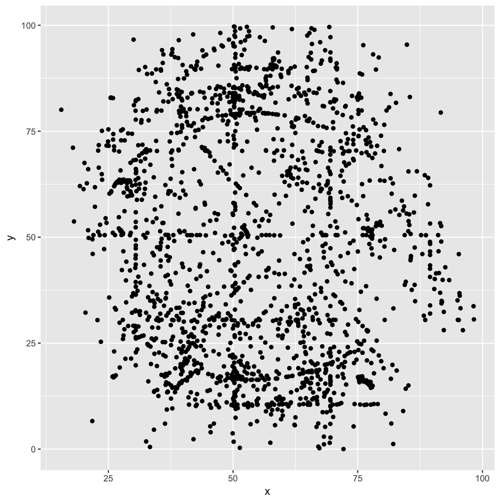

```r
ggplot(datasaurus_dozen, aes(x = x, y = y)) +
  geom_point()
```

- reuse the above command, and now colored by the `dataset` column

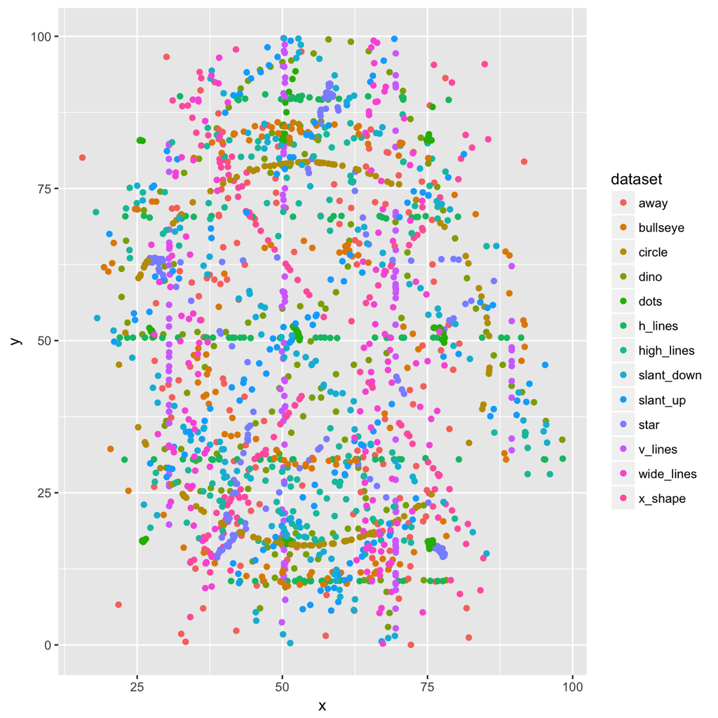

```r
ggplot(datasaurus_dozen, aes(x = x, y = y, colour = dataset)) +
  geom_point()
```

- expand now by getting one `dataset` per **facet**

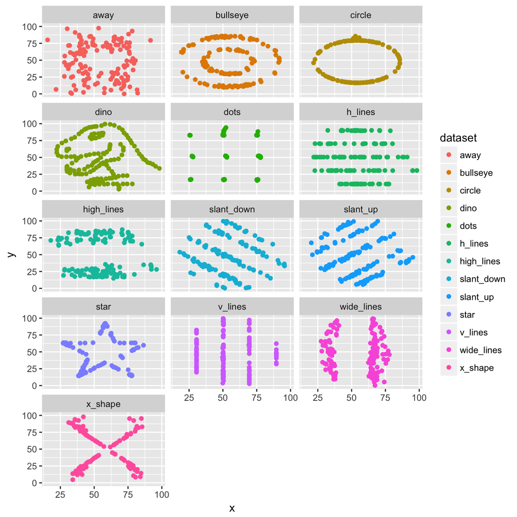

```r
ggplot(datasaurus_dozen, aes(x = x, y = y, colour = dataset)) +
  geom_point() +
  facet_wrap(~ dataset, ncol = 3)
```

- tweak the theme and use the `theme_void` and remove the legend

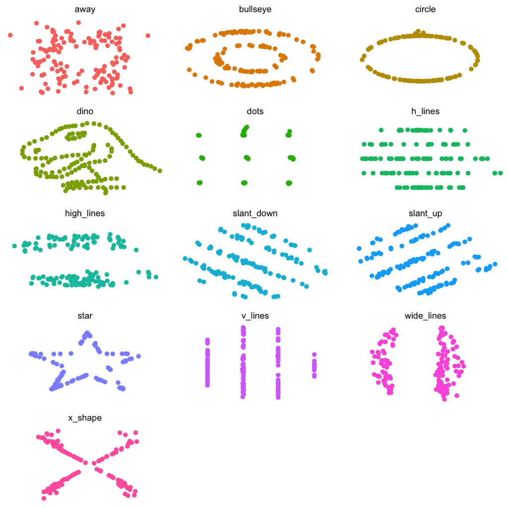

```r
ggplot(datasaurus_dozen, aes(x = x, y = y, colour = dataset)) +
  geom_point() +
  theme_void() +
  theme(legend.position = "none") +
  facet_wrap(~ dataset, ncol = 3)
```

- are the datasets actually that similar?

no ;) We were fooled by the summary stats

### Animation

-install the `gganimate` package

```r
install.packages("gganimate")
```

- add the `dataset` variable to the `frame` argument in the `aes()` function call

```
## Executing:
## convert -loop 0 -delay 100 Rplot1.png Rplot2.png Rplot3.png
##     Rplot4.png Rplot5.png Rplot6.png Rplot7.png Rplot8.png
##     Rplot9.png Rplot10.png Rplot11.png Rplot12.png Rplot13.png
##     'dino.gif'
```

```
## Output at: dino.gif
```

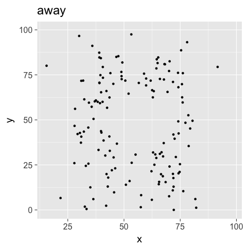

```r
library(gganimate)

p <- ggplot(datasaurus_dozen, aes(x = x, y = y, frame = dataset)) +
  geom_point() +
  theme_gray(20) +
  theme(legend.position = "none")

gganimate(p, title_frame = TRUE, "./img/dino.gif")
```

### Conclusion

> never trust summary statistics alone; always visualize your data | Alberto Cairo

**Authors**

- Alberto Cairo, (creator)
- Justin Matejka
- George Fitzmaurice
- Lucy McGowan

from this [post](https://itsalocke.com/datasaurus-now-cran/)